# Tidy Tuesday - Wk 8 2021

KVP

2/16/2021

## Load in data as data.frames

```
## [1] "freed_slaves" "census"       "furniture"    "city_rural"   "income"
## [6] "occupation"   "conjugal"     "georgia_pop"
```

```
## <environment: R_GlobalEnv>
```

## challenge01: Comparative Increase of White and Colored Population in Georgia

```r
names(georgia_pop)
```

```
## [1] "Year"    "Colored" "White"
```

```r
head(georgia_pop)
```

```
## # A tibble: 6 x 3
##    Year Colored White
##   <dbl>   <dbl> <dbl>
## 1  1790       0     0
## 2  1800     100    90
## 3  1810      78    46
## 4  1820      42    30
## 5  1830      45    55
## 6  1840      30    34
```

After looking at the data we will need to convert it from a wide to long format. Great time to practice using `pivot_longer`. First, we need to select the colums we want to convert to the long format. We select `Colored` and `White` columns so we can convert them to a single `Race` column. We will then put the values into the created `perc_change` column.

```r
georgia_pop_long <- georgia_pop %>% pivot_longer(cols = c("Colored", "White"),
                                                 names_to = "Race",
                                                 values_to = "perc_change")
```

A simple line plot of the population change over time.

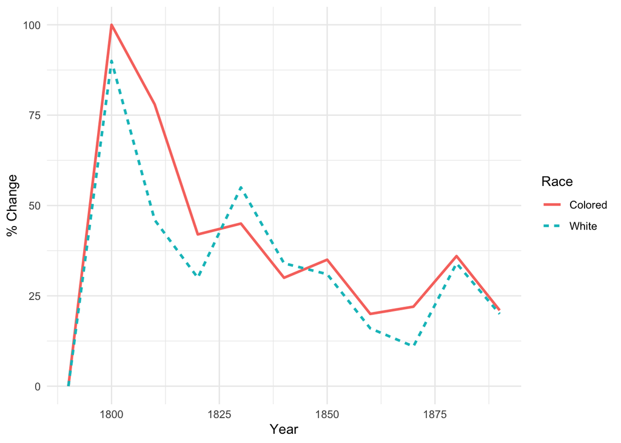

```r
ggplot(data = georgia_pop_long,
       aes(x = Year, y = perc_change, linetype = Race, color = Race)) +
  geom_line(size =1) + theme_minimal() + ylab("% Change")
```

## challenge02: Conjugal Condition

```r
head(conjugal)
```

```
## # A tibble: 6 x 5
##   Population Age         Single Married `Divorced and Widowed`
##   <chr>      <chr>        <dbl>   <dbl>                  <dbl>
## 1 Germany    15-40         62.1    37.3                    0.6
## 2 Negroes    15-40         41      54                      5
## 3 Germany    40-60          9.6    84.8                    5.6
## 4 Negroes    40-60          4.5    73.5                   22
## 5 Germany    60 and over    8.2    62.2                   29.2
## 6 Negroes    60 and over    4.5    54.5                   41
```

```r
names(conjugal)
```

```
## [1] "Population"           "Age"                  "Single"
## [4] "Married"              "Divorced and Widowed"
```

Another chance to practice `pivot_longer`!

```r
conjugal_long <- conjugal %>%
  pivot_longer(cols = c(Single, Married, `Divorced and Widowed`),
               names_to = "status", values_to = "frac") %>%
  as.data.frame()
```

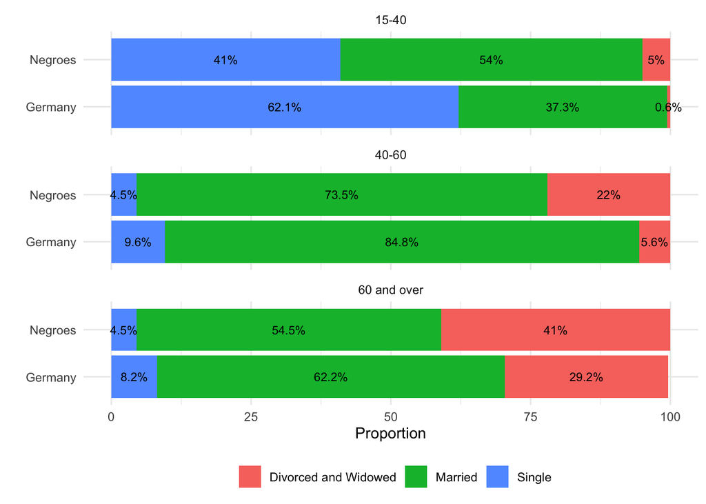

```r
ggplot(data = conjugal_long, aes(x = Population, y = frac, fill = status,
                                 label = paste(frac, "%", sep = ""))) +
  geom_bar(position="stack", stat="identity") +
  ylab("Proportion") + xlab("") +
  geom_text(size = 3, position = position_stack(vjust = 0.5)) +
  facet_wrap(vars(Age), ncol =1) + coord_flip() + theme_minimal() +
  theme(legend.position='bottom', legend.title = element_blank())
```

Had a silly typo here where I had `population` instead of `Population`

I do not know why it never dawned on me that I can flip bar charts so they are easier to read. Typically I just rotate the x-axis labels 45 degrees. Flipping the coordinates make the graphs easier to read and interpret.

Now to figure out how to change the shape of the legend color indicators from squares to circles. After some googling I found this on [stackoverflow](https://stackoverflow.com/questions/40469757/change-the-shape-of-legend-key-for-geom-bar-in-ggplot2)

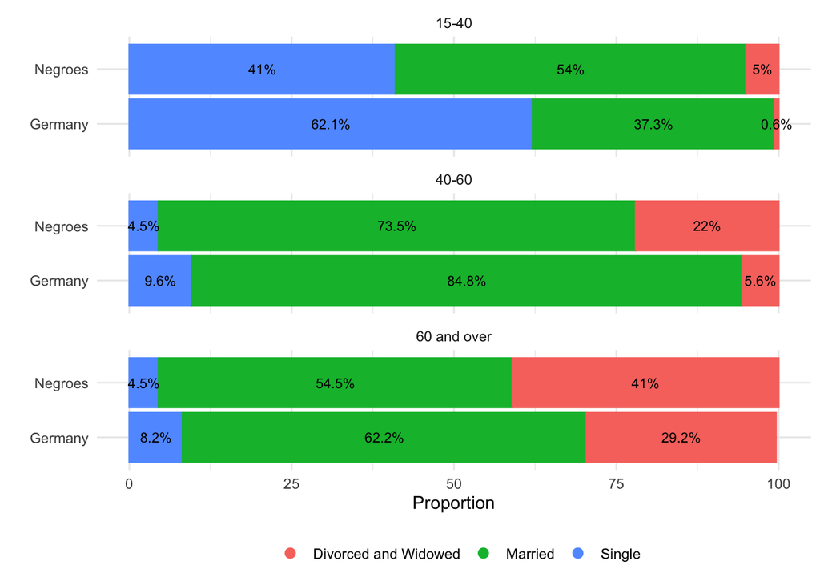

```r
df_empty = data.frame(Population = c(NA, NA, NA),
                 status = c("Divorced and Widowed", "Married", "Single"),
                 frac = as.numeric(c(NA, NA, NA)))

ggplot(data = conjugal_long, aes(x = Population, y = frac, fill = status,
                                 color = status,
                                 label = paste(frac, "%", sep = ""))) +
  geom_bar(position="stack", stat="identity", show.legend = FALSE) +
  geom_point(data = df_empty, aes(x = Population, y = frac, color = status), size=4,
             shape = 20) +
  ylab("Proportion") + xlab("") +
  geom_text(size = 3, position = position_stack(vjust = 0.5), color ="black") +
  facet_wrap(vars(Age), ncol =1) + coord_flip() + theme_minimal() +
  theme(legend.position='bottom', legend.title = element_blank(),
        legend.key = element_blank())
```

*Solved!* The above stackoverflow was a great resource. You will need to do the following: 1. Create a data frame that is empty for your x and y variables. For your fill variable, make a list of your categories. In the `df_empty` below you see that Population and frac are set to a list of `NA` while status is a list of our status categories 2. Hide the legend for the bar plot by adding `show.legend = FALSE` 3. Add a geom_point using the `df_empty` data frame. **Note you can change the shape to whatever you want your legend shape to be**

## challenge03: Occupations of Negroes and Whites in Georgia

Okay, so this one is a tricky pie chart. The plot looks like a fan that is reflected. The negro plot is the top half and the white plot is the bottom half. First I am going to make a simple pie chart for each and then if I am feelimg ambitious I will try to get the fan plot to work.

I do not make pie charts often, but when I do I always need a tutorial. The base r has a pie chart package, but I want to stick with ggplot. So I have to first make a bar chart (go figure) then apply `coord_polar`

```r
names(occupation)
```

```
## [1] "Group"      "Occupation" "Percentage"
```

```r
head(occupation)
```

```
## # A tibble: 6 x 3
##   Group   Occupation                              Percentage
##   <chr>   <chr>                                        <dbl>
## 1 Negroes Agriculture, Fisheries and Mining             62
## 2 Negroes Manufacturing and Mechanical Industries        5
## 3 Negroes Domestic and Personal Service                 28
## 4 Negroes Professions                                    0.8
## 5 Negroes Trade and Transportation                       4.5
## 6 Whites  Agriculture, Fisheries and Mining             64
```

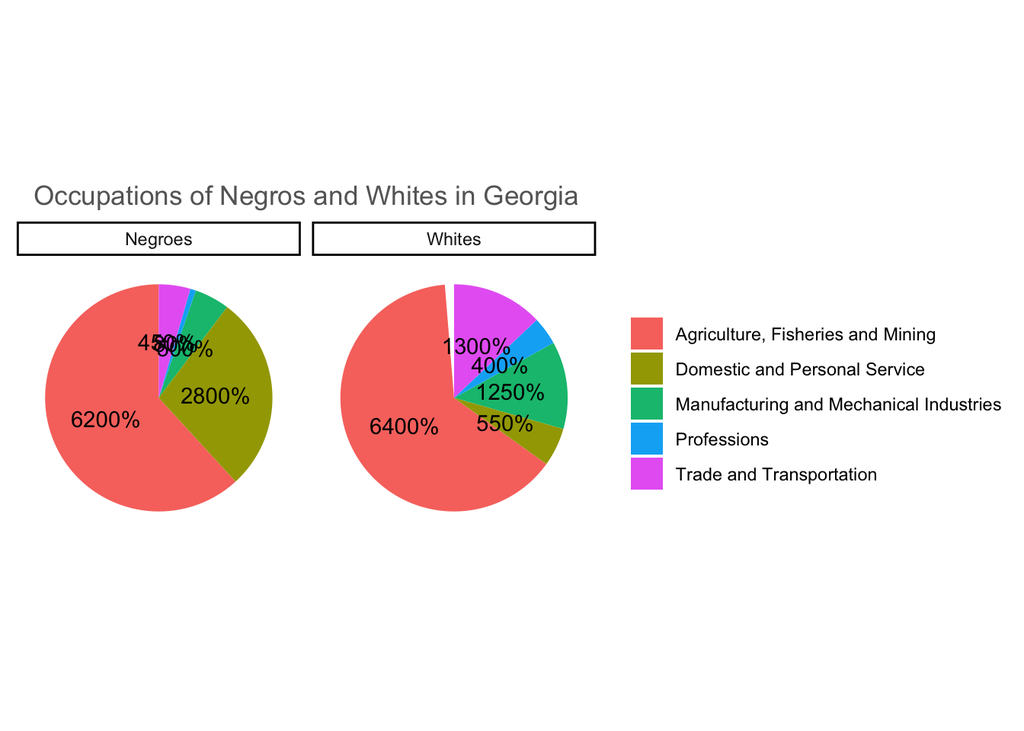

```r
ggplot(occupation, aes(x="", y=Percentage, fill=Occupation)) +
  geom_bar(stat="identity", width=1) + # Create a basic bar
  facet_wrap(vars(Group), ncol =2) +
  coord_polar("y", start=0) + # Convert to pie (polar coordinates)
  geom_text(aes(label = paste0(round(Percentage*100), "%")),
            position = position_stack(vjust = 0.5)) + # add labels
  labs(x = NULL, y = NULL, fill = NULL, title = "Occupations of Negros and Whites in Georgia") +
  theme_classic() + theme(axis.line = element_blank(),
          axis.text = element_blank(),
          axis.ticks = element_blank(),
          plot.title = element_text(hjust = 0.5, color = "#666666"))
```

Whoops `#fail`, lets try this again…

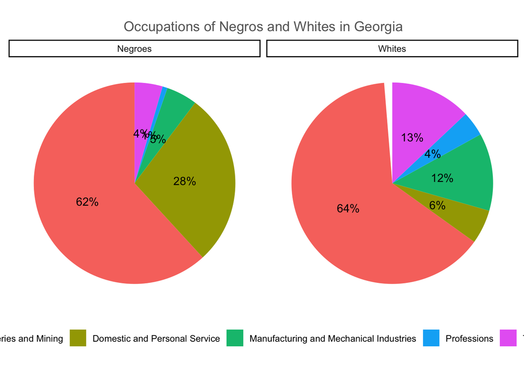

```r
ggplot(occupation, aes(x="", y=Percentage, fill=Occupation)) +
  geom_bar(stat="identity", width=1) + # Create a basic bar
  facet_wrap(vars(Group), ncol =2) +
  coord_polar("y", start=0) + # Convert to pie (polar coordinates)
  geom_text(aes(label = paste0(round(Percentage), "%")),
            position = position_stack(vjust = 0.5)) + # add labels
  labs(x = NULL, y = NULL, fill = NULL, title = "Occupations of Negros and Whites in Georgia") +
  theme_classic() + theme(axis.line = element_blank(),
          axis.text = element_blank(),
          axis.ticks = element_blank(),
          plot.title = element_text(hjust = 0.5, color = "#666666"),
          legend.position='bottom', legend.title = element_blank(),
        legend.key = element_blank())
```

## challenge04: Proportion of Freeman and Slaves Among American Negroes

```r
names(freed_slaves)
```

```
## [1] "Year"  "Slave" "Free"
```

```r
head(freed_slaves)
```

```
## # A tibble: 6 x 3
##    Year Slave  Free
##   <dbl> <dbl> <dbl>
## 1  1790  92     8
## 2  1800  88    11
## 3  1810  86.5  13.5
## 4  1820  87    13
## 5  1830  86    14
## 6  1840  87    13
```

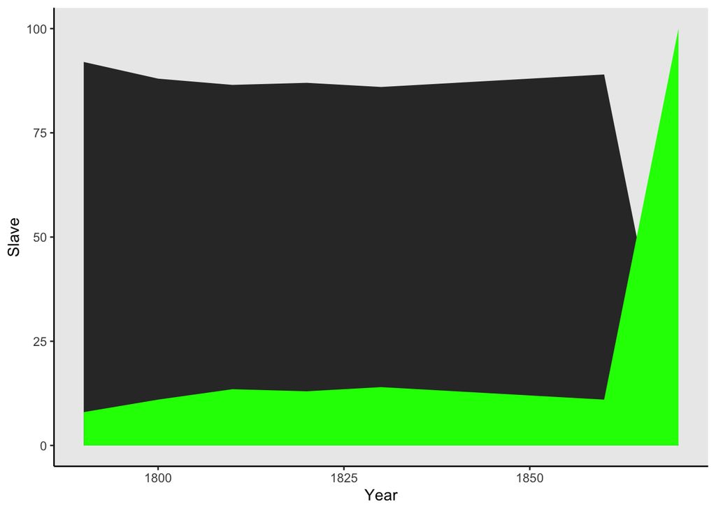

```r
ggplot(data = freed_slaves, aes(x = Year, y = Slave)) + geom_area() +
  geom_area(data = freed_slaves, aes(x = Year, y = Free) , fill = "green") +
  theme(panel.border = element_blank(),
          panel.grid.major = element_blank(),
          panel.grid.minor = element_blank(),
          axis.line = element_line(size = 0.5, linetype = "solid",
                                   colour = "black"))
```

hmm, okay, now I need to flip the Free group. After some googleing it looks like I probably need to make it into a long format datbase: https://www.r-graph-gallery.com/136-stacked-area-chart.html

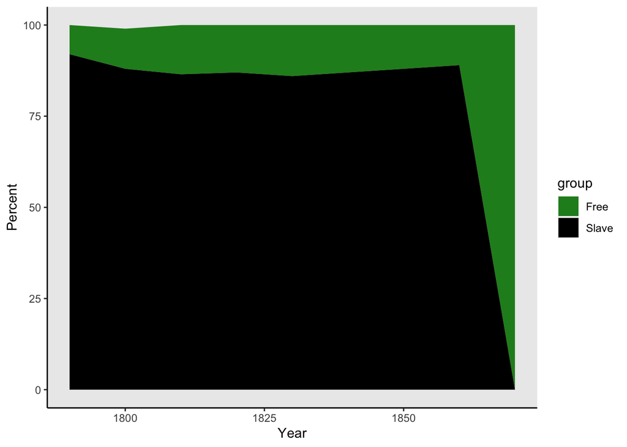

```r
freed_slaves_long <- freed_slaves %>% pivot_longer(cols = c("Slave", "Free"),
                                                   names_to = "group",
                                                   values_to = "perc")

ggplot(data = freed_slaves_long, aes(x = Year, y = perc, fill = group)) +
  geom_area() +
  ylab("Percent") +
  scale_fill_manual(values = c("forestgreen", "black")) +
  theme(panel.border = element_blank(),
          panel.grid.major = element_blank(),
          panel.grid.minor = element_blank(),
          axis.line = element_line(size = 0.5, linetype = "solid",
                                   colour = "black"))
```